# Lab 1: Introduction to R and RStudio, knitr, and tidyverse

```r
library(tidyverse)
```

# Learning Objectives

1. Install R and RStudio
2. Load data from a csv into R
3. Understand how R treats missing values and use functions to identify and remove those missing values
4. Manipulate data using the verbs in the **dplyr**
5. Use the pipe operator `%>%` to simplify complicated code by chaining expressions together
6. Create plots using the ggplot2 package.

# Installing R

Install R and RStudio

# Orientation with RStudio

R is the name of the programming language, and RStudio is a convenient and widely used interface to that language.

Since you will be using it for the remainder of the course, you should familiarize yourself with the RStudio GUI.

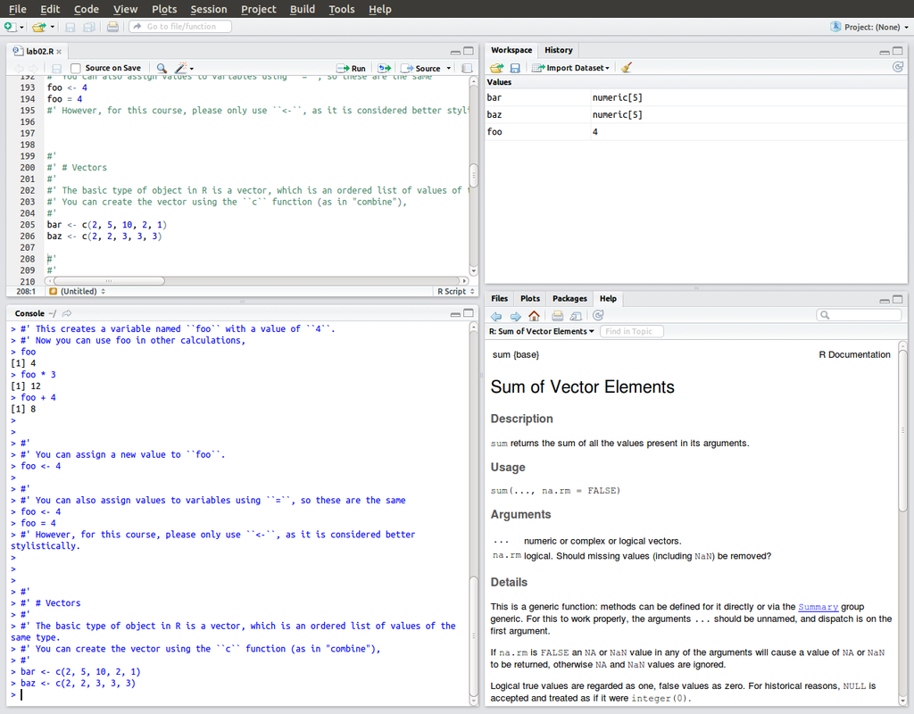

RStudio GUI

It consists of four windows,

1. Bottom left: The **console** window. You type commands at the `>` prompt and R executes them.
2. Top left: The **editor** window. Here you can edit and save R scripts which contain multiple R commands.
   - You can open a new R script using *File -> New -> R script*.
   - If you highlight an area, you can run those commands in the console with the “Run” button.
   - You can run all the commands in the **editor** window using the “Source” button.
3. Top right
   - **workspace** lists all R objects (variables) that are defined
   - **history** lists all the commands that have been typed into the console.
4. Bottom right
   - **files** allows you to browse directories and open files.
   - **plots** displays any plots created. In this window you can toggle back through previously created plots.
   - **packages** shows which packages are installed and loaded.
   - **help** displays R help.

RStudio documentation can be found at http://www.rstudio.com/ide/docs/. Of those, the most likely to be useful to you are:

- [Working in the Console](http://www.rstudio.com/ide/docs/using/console)
- [Editing and Executing Code](http://www.rstudio.com/ide/docs/using/source)
- [Viewing Command History](http://www.rstudio.com/ide/docs/using/history)

**Challenge:**

1. Go to *Tools > Global Options*. Change the font and color of the editor and console. Which one do you like the best?
2. What happens when you type `Alt+Shift+1`?

You can use `=` instead of `<-` for assignment. You may see this in some other code. There are some technical reasons to use `<-` instead of `=`, but the primary reason we will use `<-` instead of `=` is that this is the convention used in modern `R` programs.

# Working Directory and R Projects

## R Projects

Keeping all the files associated with a project organized together -input data, R scripts, analytical results, figures- is such a wise and common practice that RStudio has built-in support for this via its projects. Read [this](https://support.rstudio.com/hc/en-us/articles/200526207-Using-Projects) for more information about RStudio projects.

You will use RStudio projects for your labs and homeworks, and **final paper**. Create a RStudio project that you will use for all your labs.

1. *File -> New Project*
2. Select “New Directory”
3. Select “Empty Project”
4. Select a name for your project as Directory Name. “POLS_503_Labs” is as good as any, and better than most. Then choose where to put this directory with “Create project as sub-directory of”. Don’t worry about the other options.

# Creating your first R Markdown Document

1. *File -> New File -> R Markdown*
2. Choose a title and author for your file. HTML output is fine.
3. Hit OK. This will open a template for your Markdown file.
4. Save this file with `Ctrl-S`.
5. Click on the “Knit HTML” button. This will create a HTML document from this document.

Cheat sheets and additional resources about R Markdown are available at http://rmarkdown.rstudio.com/.

# Using R as a calculator

Although it is so much more, you can use R as a calculator. For example, to add, subtract, multiply or divide:

```r
2 + 3
2 - 3
2 * 3
2 / 3
```

The power of a number is calculated with `^`, e.g. $4^2$ is,

```r
4 ^ 2
```

R includes many functions for standard math functions. For example, the square root function is `sqrt`, e.g. $\sqrt{2}$,

```r
sqrt(2)
```

And you can combine many of them together

```r
(2 * 4 + 3 ) / 10
sqrt(2 * 2)
```

# Variables and Assignment

In R, you can save the results of calculations into objects that you can use later. This is done using the special symbol, `<-`. For example, this saves the results of 2 + 2 to an object named `foo` [^1]

```r
foo <- 2 + 2
```

You can see that `foo` is equal to `4`

```r
foo
```

And you can reuse foo in other calculations,

```r
foo + 3
foo / 2 * 8 + foo
```

# Comments

Any R code following a hash (`#`) is not executed. These are called comments, and can and **should** be used to annotate and explain your code. For example, this doesn’t do anything.

```r
#thisisacomment
```

And in this, nothing after the `#` is executed,

```r
#this is still a comment
2 + 2 # this is also a comment
```

**Challenge:** What is this equal to?

```r
5 * 4 # + 3 # - 8
```

## Missing Data

Missing data is particularly important

```r
foo <- c(1, 2, NA, 3, 4)
```

**Challenge**

1. What is the result of `2 + NA`
2. What is the result of `mean(foo)`
3. Look at the documentation of `mean` to change how that function handles missing values.
4. How does `median(foo)` work?
5. `foo > 2`. Are all the entries `TRUE` and `FALSE`?
6. What does `is.na(foo)` do? What about `! is.na(foo)` ?
7. What does `foo[! is.na(foo)]` do?

The function `na.omit` is particularly useful. It removes any row in a dataset with a missing value in *any* column. For example,

```r
dfrm <- data.frame(x = c(NA, 2, NA, 4), y = c(NA, NA, 7, 8))
na.omit(dfrm)
```

# Loading Data into R

Download the csv (“[comma-separated values](http://en.wikipedia.org/wiki/Comma-separated_values)”)" [here](https://raw.githubusercontent.com/GarciaRios/govt_6029/master/data/gapminder.csv).

Then load the file

```r
gapminder <- read.csv("gapminder.csv", stringsAsFactors = FALSE)
```

This creates a *data frame*. A *data frame* is a type of R object that corresponds to what you usually think of as a dataset or a spreadsheet — rows are observations and columns are variables.

**Challenge:** What happens when you do the following?

```r
gapminder
```

This is a lot of information. How can we get a more useful picture of the dataset as a whole?

```r
dim(gapminder)
names(gapminder)
head(gapminder)
tail(gapminder)
summary(gapminder)
```

- `dim` shows the dimensions of the data frame as the number of rows, columns
- `names` shows the column names of the data frame.
- `head` shows the first few observations
- `summary` calculates summary statistics for all variables in the data frame.

**Challenge:** Given the information previously:

1. What are the variables in the dataset?
2. How many observations are there?
3. What is the unit of observation?
4. What types of data are the different variables?
5. What is the range of years in the data?
6. What are the mean and median life expectancy?

# Working with variables in Data Frames

You can extract single variables (or columns) and perform different operations on them. To extract a variable, we use the dollar sign (`$`) extraction operator.

```r
gapminder$lifeExp
```

Again, perhaps a summary may be more interesting. We can do more specific operations on this variable alone:

```r
mean(gapminder$lifeExp)
median(gapminder$lifeExp)
sd(gapminder$lifeExp)
min(gapminder$lifeExp)
max(gapminder$lifeExp)
quantile(gapminder$lifeExp)
```

**Challenge** 1. What are the mean and median of GDP per capita? 2. Find the 30th percentile of GDP per capita? 3. How many countries in the data are there? How many years? The function `length()` calculates the length of a vector. The function `unique()` returns the number of unique values in a vector.

On your own, make sure your lab compiles neatly.Make sure that you are not printing unnecessary output.

On the class website, you can find the RMarkdown code that use to create this document. Download it and check the code that use to keep it nice and clean as well and the Markdown code that use through the text (e.g to create lists and other styling)

Some text and the data set used in this are taken from Jenny Bryant, [R basics, workspace and working directory, RStudio projects](https://stat545-ubc.github.io/block002_hello-r-workspace-wd-project.html), licensed under [CC BY-NC 3.0](http://creativecommons.org/licenses/by-nc/3.0/)

[^1]: If you are curious as to why the variable was named `foo`, read [this](http://en.wikipedia.org/wiki/Foobar).
[^2]: Dataset from the gapminder R packager. The dataset in that package is an excerpt from the [Gapminder](http://www.gapminder.org/data/) data. Gapminder data is released under the Creative Commons Attribution 3.0 Unported license. See their [terms of use](https://docs.google.com/document/pub?id=1POd-pBMc5vDXAmxrpGjPLaCSDSWuxX6FLQgq5DhlUhM).